# Optimization Methods

## Gradient Descent

# Motivation

Generally: find the minimum or maximum of a function.

## Example 1:

Find the parameters of a model which maximize the likelihood of data.

## Example 2:

Find the parameters of a model which minimize a cost function.

# What can we optimize?

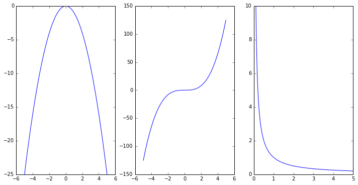

```python
import matplotlib.pyplot as plt
import numpy as np
%pylab inline
x = np.arange(-5,5, .001)
fig, subps = plt.subplots(1,3)
fig.set_size_inches(12,6)
subps[0].plot(x, -(x**2))
subps[1].plot(x, x**3)
x2 = np.arange(.1,5,.001)
subps[2].plot(x2, 1/x2)
```

# Cost functions

## Linear Regression

$$ J(\theta) = \frac{1}{N}\sum_{i=1}^N (y_i - h_\theta(x_i))^2 $$

## Logistic Regression

$$ \ln p(\vec{y}|X;\theta) = \sum_{i=1}^N (y_i \ln h_\theta (x_i) + (1- y_i)\ln(1- (h_\theta (x_i))) $$

Which comes from the binomial.

# Finding an optimium

## Calculus

?

## Find where the derivative is 0, numerically rather than analytically

# The Gradient

- The gradient is the multivariate analogue of the derivative.
- Geometrically the gradient is the direction of steepest descent.

$$ \nabla f = \sum_{i=1}^P\frac{\partial f}{\partial x_i} e_i$$

How can we use the direction of steepest descent to find the minimum of our function?

How about the maximum?

# Gradient Descent Algorithm

Follow the direction of steepest descent until convergence.

But the gradient gives us the *direction* of steepest descent, is this sufficient?

# Gradient Descent Algorithm

- $ \alpha $: Learning rate
- $ i $: Iteration
- $ j $: Feature

# Pseudo code

```python
#Pseudo code, raises errors.
new_params = dict((i,0) for i in range(k)) #Initialize parameters
while not has_converged:
    params = copy(new_params)
    for theta in params:
        new_params[theta] -= learning_rate * gradient(theta, params)
```

# Gradient Descent Convergence Criterion

- Max number of iterations
- Change in cost function $ (cost_{old} - cost_{new})/cost_{old} < \epsilon $
- Magnitude of gradient

# Demonstration: see live notebook

# Caveats

- Requires differentiable, convex function
- Only finds global optimum on globally convex function
- Convergence is asymptotic
- Requires feature scaling
- Learning rate must be chosen (well)

# Stochastic Gradient Descent

## Motivation

Problems with Gradient Descent

- Memory (data needs to fit)
- Processor (cost function over all rows is expensive)
- Online (making updates requires complete restart)

## Intuition

The *expected cost* of a single randomly chosen observation is the same!

# SGD

Use a cost function based on a single randomly chosen observation:

$$ J(\theta) = (h_\theta(x_i) - y_i)^2 $$

# Why use SGD?

- Big data
- Converges faster on average the GD
- Can work online

# Other flavors

- "batch" is sometimes used to refer to regular GD.
- guess what minibatch is?
- Online SGD: take a step every time you get a new observation
  - Optionally sunset old observations

# Newton-Raphson Method

A fancy way of choosing our learning rate $\alpha$ in GD.

$$ \theta_{i+1} = \theta_i - \frac{1}{J''(\theta)}J'(\theta) $$

# Multivariate Newton-Raphson

$$ \theta_{i+1} = \theta_{i} - [H(f(x)]^{-1}\nabla f(x) $$

What might prevent us from using this?

- Hessian has to be computed, and inverted.
- Can diverge with a bad starting position.

# The universally best optimization method to always use

```python
with open('the_universally_best_optimization_method_to_always_use.secret') as f:
    use(f)
```

```
---------------------------------------------------------------------------
IOError                                   Traceback (most recent call last)
<ipython-input-44-90975faa8030> in <module>()
----> 1 with open('the_universally_best_optimization_method_to_always_use.secret') as f:
      2     use(f)

IOError: [Errno 2] No such file or directory: 'the_universally_best_optimization_method_to_always_use.secret'
```

# Why should I care?

Q: Will you ever invent a new cost function that you need to optimize directly?

A: Probably not

But, optimization underlies everything we do as data scientists, so understanding these concerns will help you use high-level tools. Knowing what optimization approach is used for different methods is a good signal of competence.

```python
import sklearn.linear_model as lm
help(lm.LogisticRegression)
```

[output not shown]

[output cut: 274 more lines]

[output not shown]